# **Analyse de données d’écologie forestière dans le bois de Montrond**

Etude de l’abondance, de la biodiversité et de la répartition spécifique des arbres en forêt

Mathis LEHMANN, Elodie MANZANO, Celia WOTLING, Titouan HUET

```r
library("tidyverse")
library("emmeans")
library("lsmeans")
```

# 1 Etude de différentes variables

## 1.1 Etude du nombre d’individus

On peut tout d’abord s’intéresser au nombre d’arbres par placette. Une première possibilité est de le mettre en regard de la topographie ou de l’exposition. Ces deux paramètres sont les deux variables explicatives que l’on retiendra pour le reste de l’analyse de nos données. Pour cela, on peut présenter des boxplot du nombre d’arbres en fonction de la topographie ou en fonction de l’exposition.

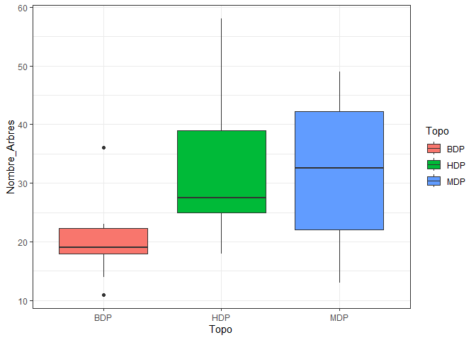

```r
cumulees<-read.csv("Cumulees.csv")
ggplot(cumulees,aes(x=Topo,y=Nombre_Arbres))+geom_boxplot(aes(fill=Topo))+theme_bw()
```

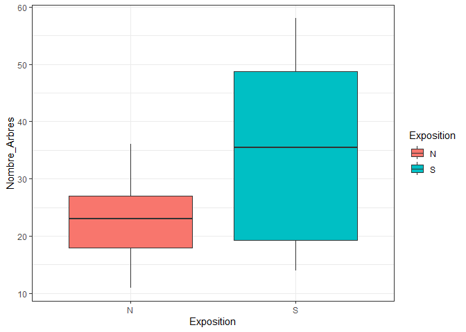

```r
ggplot(cumulees,aes(x=Exposition,y=Nombre_Arbres))+geom_boxplot(aes(fill=Exposition))+theme_bw()
```

On observe des premières tendances (plus d’individus au Sud qu’au Nord, plus d’individus en HDP et MDP qu’en BDP) que l’on va chercher à confirmer par des analyses statistiques.

Préalablement, il est nécessaire de connaître les caractéristiques de nos variables. Traçons l’histogramme pour le nombre d’arbres.

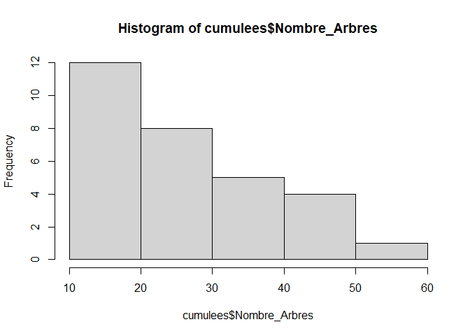

```r
hist(cumulees$Nombre_Arbres)
```

On ne peut pas considérer cette variable comme étant gaussienne. Ainsi, pour l’ANOVA, on ne peut pas utiliser le modèle linéaire. On va donc utiliser un modèle linéaire généralisé. Etant donné que nous avons ici des données de comptage, on considère notre variable comme étant de Poisson. Cela aboutit au code suivant :

```r
modexpo<-glm(cumulees$Nombre_Arbres~cumulees$Exposition,family="poisson")
summary(modexpo)
```

```
##
## Call:
## glm(formula = cumulees$Nombre_Arbres ~ cumulees$Exposition, family = "poisson")
##
## Coefficients:
##                      Estimate Std. Error z value Pr(>|z|)
## (Intercept)           3.09953    0.05307  58.400  < 2e-16 ***
## cumulees$ExpositionS  0.45378    0.06973   6.508 7.62e-11 ***
## ---
## Signif. codes:  0 '***' 0.001 '**' 0.01 '*' 0.05 '.' 0.1 ' ' 1
##
## (Dispersion parameter for poisson family taken to be 1)
##
##     Null deviance: 157.34  on 29  degrees of freedom
## Residual deviance: 114.32  on 28  degrees of freedom
## AIC: 270.95
##
## Number of Fisher Scoring iterations: 4
```

De ce modèle linéaire généralisé, on peut conclure que le nombre d’arbres est significativement différent entre les placettes exposées au Nord et celles exposées au Sud, avec 56% d’arbres en plus en cas d’exposition Sud.

```r
modtopo<-glm(cumulees$Nombre_Arbres~cumulees$Topo,family="poisson")
summary(modtopo)
```

```
##
## Call:
## glm(formula = cumulees$Nombre_Arbres ~ cumulees$Topo, family = "poisson")
##
## Coefficients:
##                  Estimate Std. Error z value Pr(>|z|)
## (Intercept)       3.00072    0.07053  42.543  < 2e-16 ***
## cumulees$TopoHDP  0.48436    0.09384   5.161 2.45e-07 ***
## cumulees$TopoMDP  0.45979    0.08714   5.277 1.32e-07 ***
## ---
## Signif. codes:  0 '***' 0.001 '**' 0.01 '*' 0.05 '.' 0.1 ' ' 1
##
## (Dispersion parameter for poisson family taken to be 1)
##
##     Null deviance: 157.34  on 29  degrees of freedom
## Residual deviance: 120.78  on 27  degrees of freedom
## AIC: 279.41
##
## Number of Fisher Scoring iterations: 4
```

```r
pairs(lsmeans(modtopo,~Topo))
```

```
##  contrast  estimate     SE  df z.ratio p.value
##  BDP - HDP  -0.4844 0.0938 Inf  -5.161  <.0001
##  BDP - MDP  -0.4598 0.0871 Inf  -5.277  <.0001
##  HDP - MDP   0.0246 0.0803 Inf   0.306  0.9497
##
## Results are given on the log (not the response) scale.
## P value adjustment: tukey method for comparing a family of 3 estimates
```

- On peut aussi réaliser un test non-paramétrique basé sur le rang, il s’agit du test de Kruskal-Wallis. Il ne nécessite aucune hypothèse préalable sur la distribution des variables.

```r
kruskal.test(cumulees$Nombre_Arbres~cumulees$Topo)
```

```
##
##  Kruskal-Wallis rank sum test
##
## data:  cumulees$Nombre_Arbres by cumulees$Topo
## Kruskal-Wallis chi-squared = 6.2287, df = 2, p-value = 0.04441
```

- On peut également réalisé un test de Wilcoxon.

```r
wilcox.test(cumulees$Nombre_Arbres[cumulees$Topo=="BDP"],cumulees$Nombre_Arbres[cumulees$Topo=="MDP"])
```

```
##
##  Wilcoxon rank sum test with continuity correction
##
## data:  cumulees$Nombre_Arbres[cumulees$Topo == "BDP"] and cumulees$Nombre_Arbres[cumulees$Topo == "MDP"]
## W = 28, p-value = 0.03704
## alternative hypothesis: true location shift is not equal to 0
```

```r
wilcox.test(cumulees$Nombre_Arbres[cumulees$Topo=="BDP"],cumulees$Nombre_Arbres[cumulees$Topo=="HDP"])
```

```
##
##  Wilcoxon rank sum test with continuity correction
##
## data:  cumulees$Nombre_Arbres[cumulees$Topo == "BDP"] and cumulees$Nombre_Arbres[cumulees$Topo == "HDP"]
## W = 15.5, p-value = 0.03198
## alternative hypothesis: true location shift is not equal to 0
```

```r
wilcox.test(cumulees$Nombre_Arbres[cumulees$Topo=="MDP"],cumulees$Nombre_Arbres[cumulees$Topo=="HDP"])
```

```
##
##  Wilcoxon rank sum test with continuity correction
##
## data:  cumulees$Nombre_Arbres[cumulees$Topo == "MDP"] and cumulees$Nombre_Arbres[cumulees$Topo == "HDP"]
## W = 47.5, p-value = 1
## alternative hypothesis: true location shift is not equal to 0
```

## 1.2 Etude de la biodiversité

Pour étudier la biodiversité dans les bois de Montrond et de la Cure, nous avons utilisé l’indice de biodiversité de Shannon. Nous cherchons si l’exposition et le niveau de pente ont un effet sur la biodiversité.

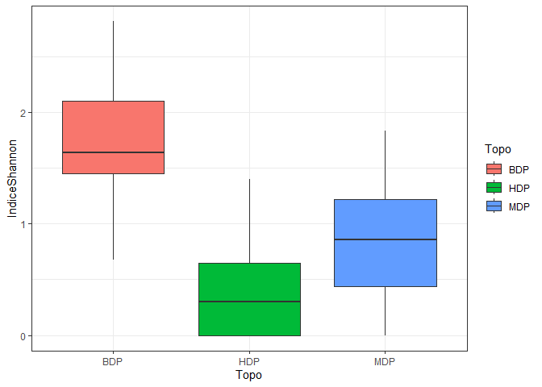

```r
ggplot(cumulees,aes(x=Topo,y=IndiceShannon))+geom_boxplot(aes(fill=Topo))+theme_bw()
```

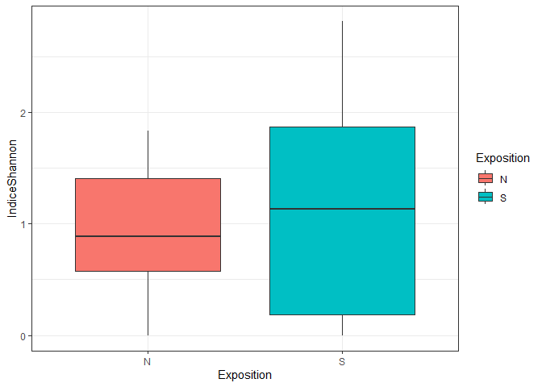

```r
ggplot(cumulees,aes(x=Exposition,y=IndiceShannon))+geom_boxplot(aes(fill=Exposition))+theme_bw()
```

Il semblerait que la biodiversité est d’autant plus forte qu’on se dirige vers le bas de pente. Quant à l’exposition, il semble que la variance de des indices de Shannon au versant S est plus forte que celle au versant nord.

On peut aller plus loin en cherchant de potentielles interactions entre l’exposition et la topographie.

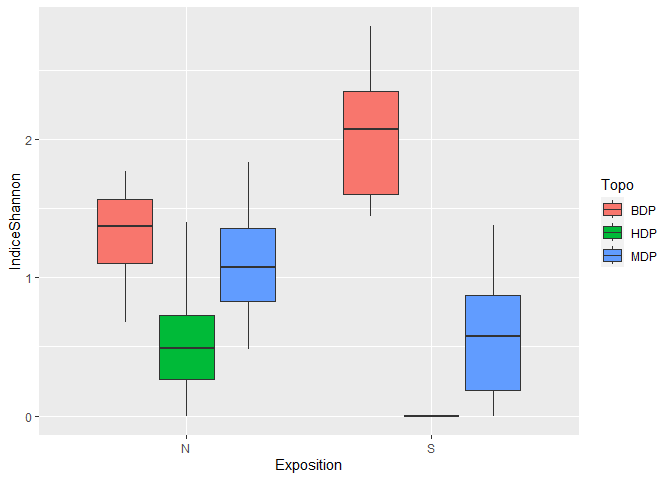

```r
ggplot(cumulees,aes(x=Exposition,y=IndiceShannon))+geom_boxplot(aes(fill=Topo))
```

A la vue du boxplot, il semblerait que l’exposition sud accentue les différences de biodiversité en fonction du niveau sur la pente. Confirmons les tendances observées quant aux impacts de l’exposition et de la topographie sur la biodiversité. Malgré le nombre limité de données avec des distributions qui ne reflètent pas exactement des lois normales (cf histogramme ci-dessous), on utilise un modèle linéaire pour réaliser des ANOVA-2.

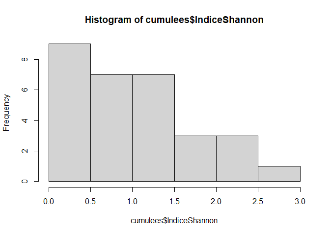

```r
hist(cumulees$IndiceShannon)
```

```r
library("lsmeans")
modelbiodiv<-lm(cumulees$IndiceShannon~cumulees$Exposition*cumulees$Topo)
anova(modelbiodiv)
```

```
## Analysis of Variance Table
##
## Response: cumulees$IndiceShannon
##                                   Df Sum Sq Mean Sq F value    Pr(>F)
## cumulees$Exposition                1 0.2401  0.2401  0.9862   0.33057
## cumulees$Topo                      2 8.3061  4.1531 17.0590 2.459e-05 ***
## cumulees$Exposition:cumulees$Topo  2 2.5819  1.2910  5.3027   0.01238 *
## Residuals                         24 5.8429  0.2435
## ---
## Signif. codes:  0 '***' 0.001 '**' 0.01 '*' 0.05 '.' 0.1 ' ' 1
```

```r
pairs(lsmeans(modelbiodiv, ~Topo))
```

```
## NOTE: Results may be misleading due to involvement in interactions
```

```
##  contrast  estimate    SE df t.ratio p.value
##  BDP - HDP    1.392 0.257 24   5.420  <.0001
##  BDP - MDP    0.821 0.214 24   3.843  0.0022
##  HDP - MDP   -0.571 0.247 24  -2.313  0.0731
##
## Results are averaged over the levels of: Exposition
## P value adjustment: tukey method for comparing a family of 3 estimates
```

On constate que la topographie a un impact significatif sur la biodiversité : plus on est bas dans la pente, plus la biodiversité est importante. La biodiversité des hauts et milieux de pente est significativement plus faible que celle des bas de pente (respectivement -75% et -50% environ). On peut dégager la même tendance entre hauts et milieux de pente, mais de manière moins significative. L’exposition en tant que telle n’a pas d’effet, cependant, il y a une interaction significative entre les deux paramètres. Une exposition Sud accentue les différences de biodiversité entre les hauts, milieux et bas de pente.

## 1.3 Etude de la répartition spécifique

Après l’étude de la biodiversité, on peut également se pencher sur des données plus précises. Par exemple, la présence des deux espèces majoritaires de chênes (pubescent ou sessile) semble varier en fonction de l’exposition. Les box plots suivants présentent le rapport sessile/(sessile + pubescent) face à une exposition Nord ou Sud.

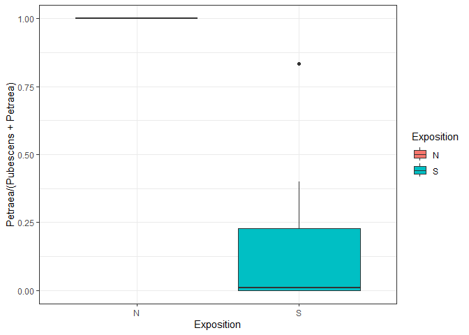

```r
ggplot(cumulees,aes(x=Exposition,y=Petraea/(Pubescens+Petraea)))+geom_boxplot(aes(fill=Exposition))+theme_bw()
```

Grâce aux tests suivants, on montre que les chênes pubescents sont significativement plus présents lorsque la placette est exposée au Sud et que les chênes sessiles sont plus présents lorsqu’elle est exposée au Nord :

```r
wilcox.test(cumulees$Pubescens[cumulees$Exposition=="N"],cumulees$Pubescens[cumulees$Exposition=="S"])
```

```
##
##  Wilcoxon rank sum test with continuity correction
##
## data:  cumulees$Pubescens[cumulees$Exposition == "N"] and cumulees$Pubescens[cumulees$Exposition == "S"]
## W = 32, p-value = 8.178e-05
## alternative hypothesis: true location shift is not equal to 0
```

```r
wilcox.test(cumulees$Petraea[cumulees$Exposition=="N"],cumulees$Petraea[cumulees$Exposition=="S"])
```

```
##
##  Wilcoxon rank sum test with continuity correction
##
## data:  cumulees$Petraea[cumulees$Exposition == "N"] and cumulees$Petraea[cumulees$Exposition == "S"]
## W = 187, p-value = 0.00148
## alternative hypothesis: true location shift is not equal to 0
```

Une anova basée sur un modèle linéaire généralisé binomial permet de conclure :

```r
mod <- glm(cbind(Petraea, Pubescens) ~ Exposition, data = cumulees,
            family = binomial(logit))
mod0 <- glm(cbind(Petraea, Pubescens) ~ 1, data = cumulees,
            family = binomial(logit))
anova(mod,mod0,test="Chisq")
```

```
## Analysis of Deviance Table
##
## Model 1: cbind(Petraea, Pubescens) ~ Exposition
## Model 2: cbind(Petraea, Pubescens) ~ 1
##   Resid. Df Resid. Dev Df Deviance  Pr(>Chi)
## 1        22      95.60
## 2        23     645.03 -1  -549.43 < 2.2e-16 ***
## ---
## Signif. codes:  0 '***' 0.001 '**' 0.01 '*' 0.05 '.' 0.1 ' ' 1
```

Elle montre en effet une différence significative dans la répartition des chênes pubescents et sessiles au Nord et au Sud, confirmant ainsi les tendances observées sur les boxplots ainsi que la conclusion tirée des tests de Wilcoxon.

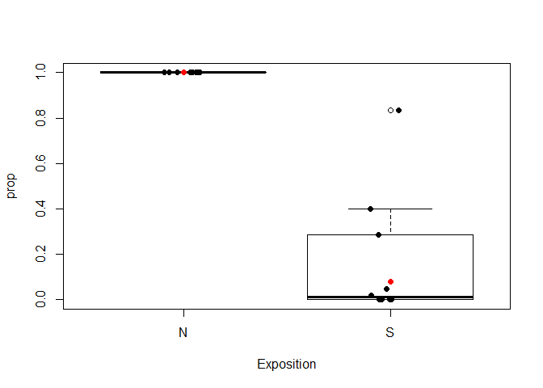

```r
cumulees$prop<-(cumulees$Petraea)/(cumulees$Petraea+cumulees$Pubescens)
mod1 <- glm(prop ~ Exposition, data = cumulees,
            family = binomial(logit),weights=Petraea+Pubescens)
xv <- c("N","S")
# y values
yv <- predict(mod1, list(Exposition = xv), type = "response")
# plot the raw data
boxplot(prop~Exposition, data=cumulees,col = "white")
# Points
stripchart(prop ~ Exposition,
           data = cumulees,
           method = "jitter",
           pch = 19,
           vertical = TRUE,
           add = TRUE)
# use the lines function to add the fitted lines
data2=data.frame(cbind(prop=yv,Exposition=xv))
stripchart(prop ~ Exposition,
           data = data2,
           pch = 19,
           col = "red",
           vertical = TRUE,
           add = TRUE)
```

Mais comment expliquer cette différence d’un point de vue biologique ? Il est reconnu que le chêne pubescent est une espèce heliophile et thermophile. Il est donc logique de le retrouver en grande majorité sur les versants Sud. Une hypothèse peut-être proposée pour expliquer cette heliophilie/thermophilie. Pour cela, il faut s’intéresser aux feuilles de ces deux arbres :

[figure not shown]

Détail d’une feuille de chêne pubescent.

[figure not shown]

Détail d’une feuille de chêne sessile.

Comme son nom l’indique, le chêne pubescent présente sur la face inférieure de ses feuilles des “poils” courts et mous. Cela leur donne un aspect duveteux visible sur l’image ci-dessus (caractère absent chez le chêne sessile). Il est possible que ce duvet permette à la feuille de maintenir une couche limite diminuant la transpiration foliaire. Ainsi, le chêne pubescent, au contraire du chêne sessile, peut résister à des conditions plus chaudes et plus arides.

## 1.4 Etude du recouvrement du sol

On s’intéresse ensuite au recouvrement du sol, en particulier par la litère et le sol nu en fonction de la topographie.

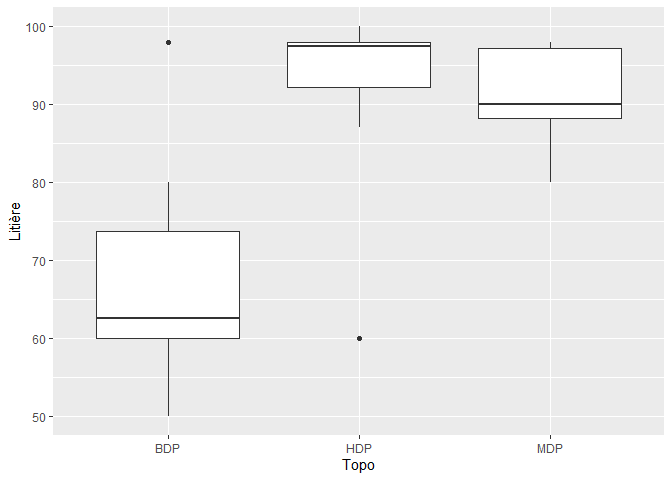

```r
infos<-read.csv("Infos.csv")
ggplot(infos, aes(x=Topo,y=Litière)) + geom_boxplot()
```

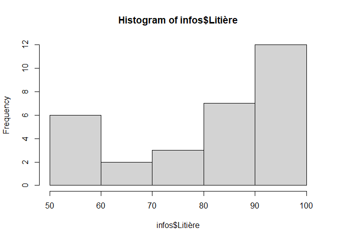

```r
hist(infos$Litière)
```

```r
lm1<-lm(infos$Litière~infos$Topo)
summary(lm1)
```

```
##
## Call:
## lm(formula = infos$Litière ~ infos$Topo)
##
## Residuals:
##    Min     1Q Median     3Q    Max
## -31.50  -6.80   0.75   6.50  31.20
##
## Coefficients:
##               Estimate Std. Error t value Pr(>|t|)
## (Intercept)     66.800      3.667  18.214  < 2e-16 ***
## infos$TopoHDP   24.700      5.501   4.490  0.00012 ***
## infos$TopoMDP   24.200      4.966   4.873 4.28e-05 ***
## ---
## Signif. codes:  0 '***' 0.001 '**' 0.01 '*' 0.05 '.' 0.1 ' ' 1
##
## Residual standard error: 11.6 on 27 degrees of freedom
## Multiple R-squared:  0.5223, Adjusted R-squared:  0.4869
## F-statistic: 14.76 on 2 and 27 DF,  p-value: 4.666e-05
```

```r
anova(lm1)
```

```
## Analysis of Variance Table
##
## Response: infos$Litière
##            Df Sum Sq Mean Sq F value    Pr(>F)
## infos$Topo  2 3970.3  1985.1  14.759 4.666e-05 ***
## Residuals  27 3631.6   134.5
## ---
## Signif. codes:  0 '***' 0.001 '**' 0.01 '*' 0.05 '.' 0.1 ' ' 1
```

```r
kruskal.test(infos$Litière~infos$Topo)
```

```
##
##  Kruskal-Wallis rank sum test
##
## data:  infos$Litière by infos$Topo
## Kruskal-Wallis chi-squared = 12.37, df = 2, p-value = 0.00206
```

La distribution étant assez éloignée d’une distribution normale, on effectue également un test de Kruskal-Wallis qui est significatif. On a bien un effet significatif de la topographie sur la couverture du sol par la litière. La topographie explique presque 50% de la variance observée.

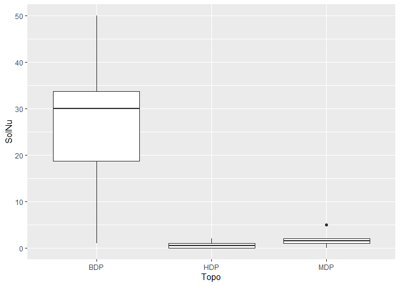

```r
ggplot(infos, aes(x=Topo,y=SolNu)) + geom_boxplot()
```

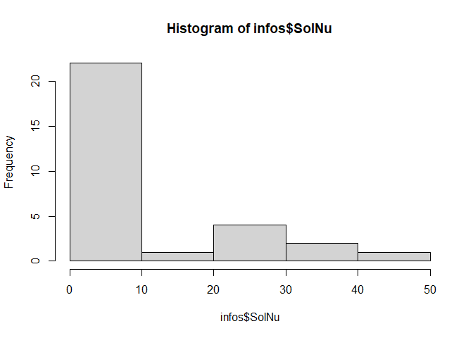

```r
hist(infos$SolNu)
```

```r
kruskal.test(infos$SolNu~infos$Topo)
```

```
##
##  Kruskal-Wallis rank sum test
##
## data:  infos$SolNu by infos$Topo
## Kruskal-Wallis chi-squared = 17.589, df = 2, p-value = 0.0001516
```

```r
lm2<-lm(infos$SolNu~infos$Topo)
summary(lm2)
```

```
##
## Call:
## lm(formula = infos$SolNu ~ infos$Topo)
##
## Residuals:
##      Min       1Q   Median       3Q      Max
## -25.5000  -0.8333   0.1667   3.1667  23.5000
##
## Coefficients:
##               Estimate Std. Error t value Pr(>|t|)
## (Intercept)     26.500      2.794   9.484 4.37e-10 ***
## infos$TopoHDP  -25.875      4.191  -6.173 1.34e-06 ***
## infos$TopoMDP  -24.667      3.783  -6.520 5.44e-07 ***
## ---
## Signif. codes:  0 '***' 0.001 '**' 0.01 '*' 0.05 '.' 0.1 ' ' 1
##
## Residual standard error: 8.836 on 27 degrees of freedom
## Multiple R-squared:  0.6671, Adjusted R-squared:  0.6424
## F-statistic: 27.05 on 2 and 27 DF,  p-value: 3.562e-07
```

```r
anova(lm2)
```

```
## Analysis of Variance Table
##
## Response: infos$SolNu
##            Df Sum Sq Mean Sq F value    Pr(>F)
## infos$Topo  2 4223.8 2111.91   27.05 3.562e-07 ***
## Residuals  27 2108.0   78.08
## ---
## Signif. codes:  0 '***' 0.001 '**' 0.01 '*' 0.05 '.' 0.1 ' ' 1
```

Il y a significativement moins de litière qui recouvre le sol en bas de pente par rapport au haut de pente et milieu de pente. Le sol nu est significativement plus présent en bas de pente.

## 1.5 Etude de la hauteur des strates

D’autres mesures susceptibles d’être analysées sont les hauteurs moyennes des strates.

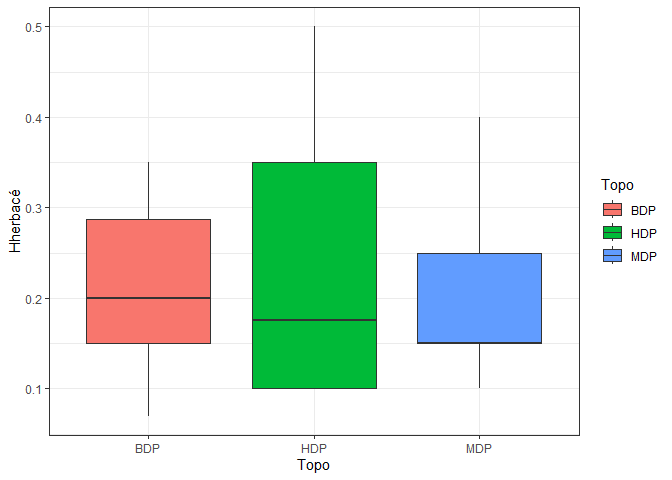

```r
infos<-read.csv("Infos.csv")
ggplot(infos, aes(x=Topo,y=Hherbacé)) + geom_boxplot(aes(fill=Topo)) + theme_bw()
```

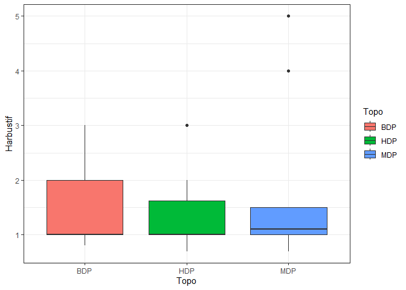

```r
ggplot(infos, aes(x=Topo,y=Harbustif)) + geom_boxplot(aes(fill=Topo))+ theme_bw()
```

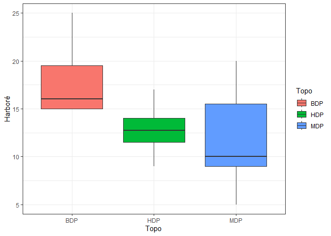

```r
ggplot(infos, aes(x=Topo,y=Harboré)) + geom_boxplot(aes(fill=Topo)) + theme_bw()
```

Faisons une analyse ANOVA pour connaître l’impact de la topographie sur hauteur de la strate arborée. On considère cette variable commme gaussienne (cf histogramme ci-dessous puis le “check_normality”).

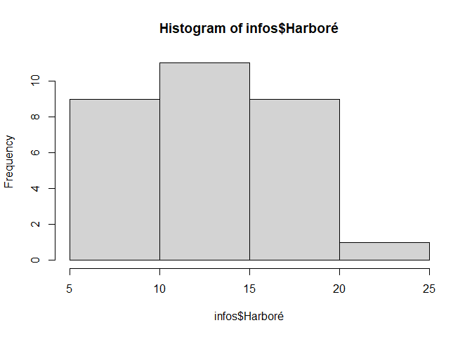

```r
library(performance)
hist(infos$Harboré)
```

```r
mod3<-lm(infos$Harboré~infos$Topo,cumulees=infos )
summary(mod3)
```

```
##
## Call:
## lm(formula = infos$Harboré ~ infos$Topo, cumulees = infos)
##
## Residuals:
##     Min      1Q  Median      3Q     Max
## -7.0000 -2.5000 -0.7187  2.8750  8.0000
##
## Coefficients:
##               Estimate Std. Error t value Pr(>|t|)
## (Intercept)     17.500      1.203  14.547  2.7e-14 ***
## infos$TopoHDP   -4.563      1.804  -2.528  0.01761 *
## infos$TopoMDP   -5.500      1.629  -3.377  0.00224 **
## ---
## Signif. codes:  0 '***' 0.001 '**' 0.01 '*' 0.05 '.' 0.1 ' ' 1
##
## Residual standard error: 3.804 on 27 degrees of freedom
## Multiple R-squared:  0.3146, Adjusted R-squared:  0.2638
## F-statistic: 6.196 on 2 and 27 DF,  p-value: 0.006101
```

```r
check_normality(mod3)
```

```
## OK: residuals appear as normally distributed (p = 0.065).
```

```r
check_heteroskedasticity(mod3)
```

```
## OK: Error variance appears to be homoscedastic (p = 0.402).
```

```r
anova(mod3)
```

```
## Analysis of Variance Table
##
## Response: infos$Harboré
##            Df Sum Sq Mean Sq F value   Pr(>F)
## infos$Topo  2 179.32  89.661  6.1959 0.006101 **
## Residuals  27 390.72  14.471
## ---
## Signif. codes:  0 '***' 0.001 '**' 0.01 '*' 0.05 '.' 0.1 ' ' 1
```

La topographie a donc un impact significatif sur la hauteur de la strate arborée. Les hauteurs moyennes des strates arborées des milieux et hauts de pente sont respectivement 31% et 26% plus basses que celle des bas de pentes.

# 2 Etude de la répartition des espèces

Pour étudier la répartition des espèces dans la forêt, on va d’abord s’intéresser à la proximité des différentes placettes en terme d’espèces qu’elles présentent. On cherche à voir si des placettes de mêmes conditions (position sur la pente et exposition) présentent des espèces similaires. Pour ce faire, on utilise une l’indice de Sorensen qui compare les placettes 2 à 2.

```r
placet<-c()
topo<-c()
expo<-c()

placet<-c(placet,'P1.1')
topo<-c(topo,'HDP')
expo<-c(expo,'N')

placet<-c(placet,'P1.2')
topo<-c(topo,'HDP')
expo<-c(expo,'N')

placet<-c(placet,'P2.1')
topo<-c(topo,'MDP')
expo<-c(expo,'N')

placet<-c(placet,'P2.2')
topo<-c(topo,'MDP')
expo<-c(expo,'N')

placet<-c(placet,'P3.1')
topo<-c(topo,'BDP')
expo<-c(expo,'N')

placet<-c(placet,'P3.2')
topo<-c(topo,'BDP')
expo<-c(expo,'N')

placet<-c(placet,'P4.1')
topo<-c(topo,'BDP')
expo<-c(expo,'S')

placet<-c(placet,'P4.2')
topo<-c(topo,'BDP')
expo<-c(expo,'S')

placet<-c(placet,'P5.1')
topo<-c(topo,'MDP')
expo<-c(expo,'S')

placet<-c(placet,'P5.2')
topo<-c(topo,'MDP')
expo<-c(expo,'S')

placet<-c(placet,'P6.1')
topo<-c(topo,'HDP')
expo<-c(expo,'S')

placet<-c(placet,'P6.2')
topo<-c(topo,'HDP')
expo<-c(expo,'S')

placet<-c(placet,'P7.1')
topo<-c(topo,'HDP')
expo<-c(expo,'N')

placet<-c(placet,'P7.2')
topo<-c(topo,'HDP')
expo<-c(expo,'N')

placet<-c(placet,'P8.1')
topo<-c(topo,'MDP')
expo<-c(expo,'N')

placet<-c(placet,'P8.2')
topo<-c(topo,'MDP')
expo<-c(expo,'N')

placet<-c(placet,'P9.1')
topo<-c(topo,'BDP')
expo<-c(expo,'N')

placet<-c(placet,'P9.2')
topo<-c(topo,'BDP')
expo<-c(expo,'N')

placet<-c(placet,'P10.1')
topo<-c(topo,'BDP')
expo<-c(expo,'S')

placet<-c(placet,'P10.2')
topo<-c(topo,'BDP')
expo<-c(expo,'S')

placet<-c(placet,'P11.1')
topo<-c(topo,'MDP')
expo<-c(expo,'S')

placet<-c(placet,'P11.2')
topo<-c(topo,'MDP')
expo<-c(expo,'S')

placet<-c(placet,'P12.1')
topo<-c(topo,'HDP')
expo<-c(expo,'S')

placet<-c(placet,'P12.2')
topo<-c(topo,'HDP')
expo<-c(expo,'S')

placet<-c(placet,'P14.1')
topo<-c(topo,'MDP')
expo<-c(expo,'N')

placet<-c(placet,'P14.2')
topo<-c(topo,'MDP')
expo<-c(expo,'N')

placet<-c(placet,'P16.1')
topo<-c(topo,'BDP')
expo<-c(expo,'S')

placet<-c(placet,'P16.2')
topo<-c(topo,'BDP')
expo<-c(expo,'S')

placet<-c(placet,'P17.1')
topo<-c(topo,'MDP')
expo<-c(expo,'S')

placet<-c(placet,'P17.2')
topo<-c(topo,'MDP')
expo<-c(expo,'S')


df<-data.frame(
  placette = placet,
  topographie = topo,
  exposition = expo
)

df
```

```
##    placette topographie exposition
## 1      P1.1         HDP          N
## 2      P1.2         HDP          N
## 3      P2.1         MDP          N
## 4      P2.2         MDP          N
## 5      P3.1         BDP          N
## 6      P3.2         BDP          N
## 7      P4.1         BDP          S
## 8      P4.2         BDP          S
## 9      P5.1         MDP          S
## 10     P5.2         MDP          S
## 11     P6.1         HDP          S
## 12     P6.2         HDP          S
## 13     P7.1         HDP          N
## 14     P7.2         HDP          N
```

[output cut: 16 more lines]

```r
presence_especes<-read.csv('Arbres_compiles.csv')
noms<-names(presence_especes)


#Fonction qui calcule l'indice de Sorensen de deux placettes à partir de la liste des espèces présentes dans ces placettes.

calc_indice_sorensen<-function(lsp1,lsp2){
  c<-sum(as.numeric(lsp2)&as.numeric(lsp1))
  sp1<-sum(lsp1)
  sp2<-sum(lsp2)
  index<- c/((sp1+sp2)/2)
  return(index)
}

matricecomparaison<-matrix(data = NA, nrow = 30 , ncol = 30, byrow = FALSE,
       dimnames = list(noms[2:31],noms[2:31]))

matricecomparaison<-sapply(noms[2:31],function(i){
  sapply(noms[2:31],function(j){
    #cat("i",i,"\n");
    #cat("j",j,"\n");
matricecomparaison[i,j]<<-calc_indice_sorensen(presence_especes[,i],presence_especes[,j])})})

library(pheatmap)
row.names(df)=gsub("\\.","_",df[,1])
mat_col=data.frame(topo=df[,2])
row.names(mat_col)=gsub("\\.","_",df[,1])
mat_row=data.frame(expo=df[,3])
row.names(mat_row)=gsub("\\.","_",df[,1])
```

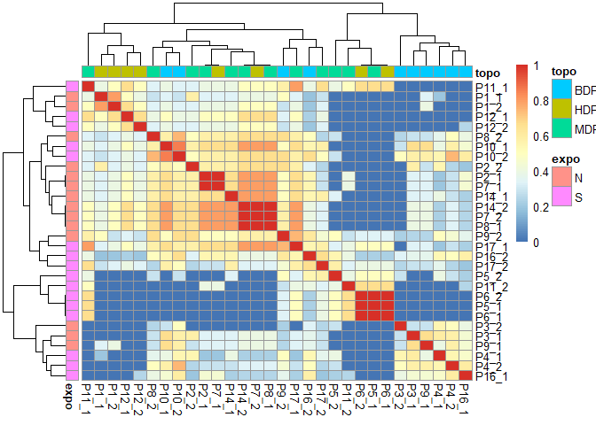

```r
pheatmap(matricecomparaison, annotation_col = mat_col, annotation_row = mat_row)
```

Ici, on constate déjà une certaine ségrégation des placettes de bas de pente, tandis que celle de haut et de milieu de pente sont un peu plus mélangées. Aussi, on n’a aucun rapprochement direct entre les placettes de bas de pente et celles de haut de pente, on passe systématiquement par un milieu de pente d’abord. En terme de répartition des espèces, on aurait donc un changement progressif de la répartition des espèces des bas de pente vers les hauts de pente. La ségrégation entre placettes versant nord et placettes versant sud est moins marquée que pour le niveau de pente. Les espèces ne semblent pas tant changer d’un versant à l’autre.

# 3 Analyse factorielle des correspondances sur les individus

Afin de trouver les composantes expliquant les variations de la distribution des espèces, nous avons réalisé une AFC.

```r
library("ade4")
diversite<-read.csv("Diversite.csv")
elim=c("Placette","Sous_placette","Topo","Exposition")
diversite2=diversite[,!names(diversite)%in%elim]
test<-dudi.coa(diversite2,scannf=FALSE)
test
```

```
## Duality diagramm
## class: coa dudi
## $call: dudi.coa(df = diversite2, scannf = FALSE)
##
## $nf: 2 axis-components saved
## $rank: 16
## eigen values: 0.8406 0.6481 0.4069 0.3827 0.2084 ...
##   vector length mode    content
## 1 $cw    20     numeric column weights
## 2 $lw    30     numeric row weights
## 3 $eig   16     numeric eigen values
##
##   data.frame nrow ncol content
## 1 $tab       30   20   modified array
## 2 $li        30   2    row coordinates
## 3 $l1        30   2    row normed scores
## 4 $co        20   2    column coordinates
## 5 $c1        20   2    column normed scores
## other elements: N
```

```r
afc<-dudi.coa(df=diversite2, scannf=FALSE, nf=2)
```

On obtient donc :

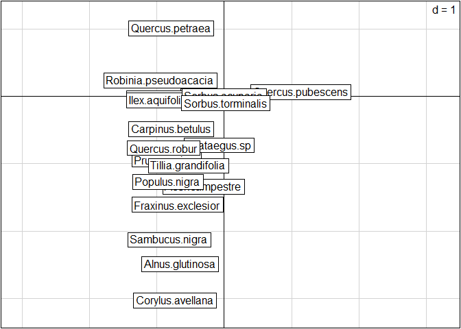

```r
s.label(afc$co, xax = 1, yax = 2)
```

On observe ici l’importance des Quercus pubescens (chêne pubescent) et Quercus petraea (chêne sessile) dans la constitution de l’axe 1. Cela rappelle l’analyse sur la distribution des chênes plus haut. Ceci peut être quantifié par la commande suivante :

```r
library("factoextra")
```

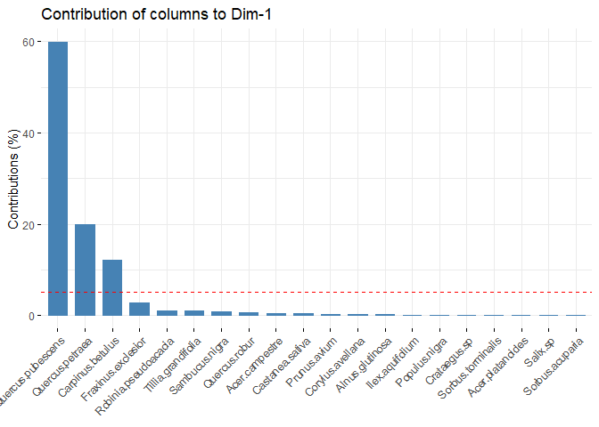

```r
fviz_contrib(afc, choice="col")
```

L’explication est plus complexe pour l’axe 2. La commande suivant nous montre que le chêne sessile, et dans une moindre mesure le frêne et l’érable champêtre drivent cet axe.

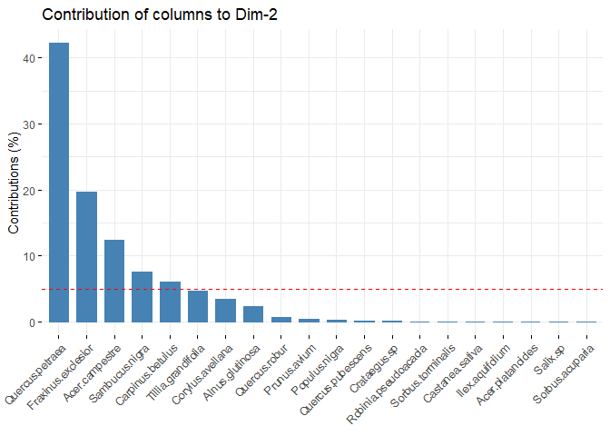

```r
fviz_contrib(afc, choice="col", axes=2)
```

Néanmoins, il faut nuancer cette explication. En effet, les chênes sont présents en grand nombre. Or, cette analyse est basée sur la loi du chi2, loi influencée par l’effectif.

A présent, essayons de faire ressortir nos paramètres (exposition et topographie) sur cette AFC.

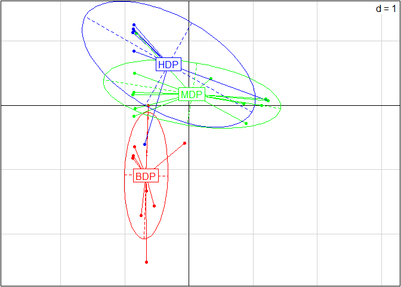

```r
topo<-as.factor(diversite$Topo)
exposition<-as.factor(diversite$Exposition)
gcol <- c("red", "blue","green")
gcol1<-c("black","orange")
s.class(dfxy = afc$li, fac = topo, col = gcol, xax = 1, yax = 2)
```

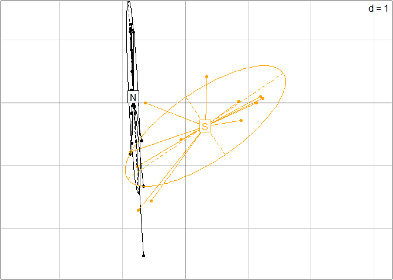

```r
s.class(dfxy = afc$li, fac = exposition, col = gcol1, xax = 1, yax = 2)
```

Cela facilite une potentielle interprétation. L’axe 1 est en partie expliqué par l’exposition car cet axe segrege selon Nord et Sud. Donc, des espèces sont plus spécifiques du Sud que du Nord et inversement. L’axe 2 est plutôt expliqué par la topographie puisqu’on y observe un gradient de pente : BDP puis MDP et HDP. Donc, des espèces sont plus spécifiques du BDP et que du MDP et HDP et inversement.

Cherchons à quantifier cela via une BCA.

```r
bcatopo<-bca(x=afc, fac=topo, scannf=FALSE, nf=2)
bcaexp<-bca(x=afc, fac=exposition, scannf=FALSE, nf=2)
bcatopo
```

```
## Between analysis
## call: bca.dudi(x = afc, fac = topo, scannf = FALSE, nf = 2)
## class: between dudi
##
## $nf (axis saved) : 2
## $rank:  2
## $ratio:  0.1927577
##
## eigen values: 0.5351 0.09076
##
##   vector length mode    content
## 1 $eig   2      numeric eigen values
## 2 $lw    3      numeric group weigths
## 3 $cw    20     numeric col weigths
##
##   data.frame nrow ncol content
## 1 $tab       3    20   array class-variables
## 2 $li        3    2    class coordinates
## 3 $l1        3    2    class normed scores
## 4 $co        20   2    column coordinates
## 5 $c1        20   2    column normed scores
## 6 $ls        30   2    row coordinates
## 7 $as        2    2    inertia axis onto between axis
```

```r
bcaexp
```

```
## Between analysis
## call: bca.dudi(x = afc, fac = exposition, scannf = FALSE, nf = 2)
## class: between dudi
##
## $nf (axis saved) : 1
## $rank:  1
## $ratio:  0.1813278
##
## eigen values: 0.5888
##
##   vector length mode    content
## 1 $eig   1      numeric eigen values
## 2 $lw    2      numeric group weigths
## 3 $cw    20     numeric col weigths
##
##   data.frame nrow ncol content
## 1 $tab       2    20   array class-variables
## 2 $li        2    1    class coordinates
## 3 $l1        2    1    class normed scores
## 4 $co        20   1    column coordinates
## 5 $c1        20   1    column normed scores
## 6 $ls        30   1    row coordinates
## 7 $as        2    1    inertia axis onto between axis
```

Ceci nous informe que la topographie explique 19,3% de la variabilité des données. L’exposition en explique, elle, 18,1%.

En complément de cette BCA, on peut réaliser une analyse discriminante.

```r
afc2<-dudi.coa(df=diversite2, scannf=FALSE, nf=ncol(diversite2)-1)
dis1<-discrimin(dudi=afc2, fac=as.factor(diversite$Exposition), scannf=FALSE)
dis2<-discrimin(dudi=afc2, fac=as.factor(diversite$Topo), scannf=FALSE)
```

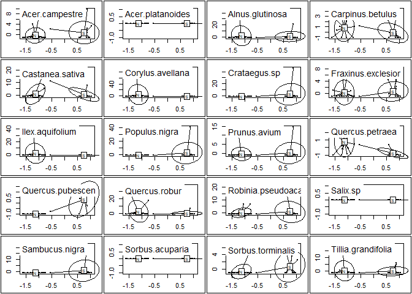

```r
plot(dis1)
```

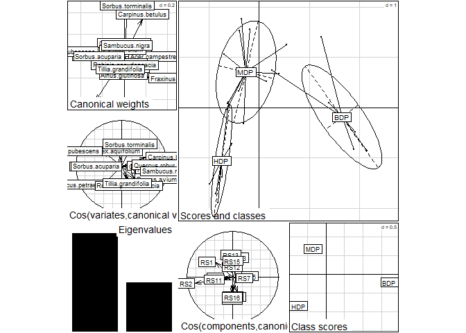

```r
plot(dis2)
```